# Orca

| **Model** | `AcousticsToolbox.Orca` |
| --- | --- |
| **Description** | [Orca normal mode model](https://oalib-acoustics.org/models-and-software/normal-modes/) (wrapper) |
| **Language** | Fortran |
| **Advantages** | Well-established benchmark model |
| **Limitations** | Not differentiable |

```
Orca(env; kwargs...)
```

Create a Orca propagation model.

Supported keyword arguments:

- `dz`: vertical step size for sampling modes in m (default: 0.1)
- `complex_solver`: selects between real/complex solver (default: `true`)
- `cphmin`: minimum phase speed in m/s (default: 0, 0=auto)
- `cphmax`: maximum phase speed in m/s (default: 0, 0=auto)
- `rmin`: minimum range of interest in m (default: 0, 0=auto)
- `rmax`: maximum range of interest in m (default: 0, 0=auto)
- `phfac`: phase step parameter (default: 0, 0=auto)
- `db_cut`: dB cutoff for weak modes (default: 0, 0=auto)
- `temp_dir`: directory for temporary files (default: system temp directory)
- `debug`: debug mode (default: false)

Enabling debug mode will create a temporary directory with the Orca input and output files. This allows manual inspection of the files.

A good overview of the Orca model can be found at:

- [ORCA guide](https://oalib-acoustics.org/website_resources/Modes/orca/orca_guide_v3_0.pdf) (January 30, 2002).

**Tip**

The theory of modal models is summarized in a brief note “On modal models”. It provides an overview of key concepts and relevant mathematical formulations.

## Examples

### Range-independent scenario

Here’s an example showing results for a simple test problem:

```julia
using UnderwaterAcoustics
using AcousticsToolbox
using Plots

env = UnderwaterEnvironment(
  bathymetry = 100,
  seabed = FineSand
)
pm = Orca(env)

tx = AcousticSource(0, -50, 300)
rx = AcousticReceiver(5000, -50)
modes = arrivals(pm, tx, rx)
```

```
17 element Vector{ModeArrival}:
  mode 1: kᵣ = 1.224473 - 2.0e-6im rad/m, v = 1538.47 m/s, vₚ = 1539.40 m/s
  mode 2: kᵣ = 1.22333 - 7.0e-6im rad/m, v = 1537.12 m/s, vₚ = 1540.84 m/s
  mode 3: kᵣ = 1.221422 - 1.5e-5im rad/m, v = 1534.85 m/s, vₚ = 1543.25 m/s
  mode 4: kᵣ = 1.218745 - 2.6e-5im rad/m, v = 1531.66 m/s, vₚ = 1546.64 m/s
  mode 5: kᵣ = 1.215292 - 4.0e-5im rad/m, v = 1527.54 m/s, vₚ = 1551.03 m/s
  mode 6: kᵣ = 1.211055 - 5.6e-5im rad/m, v = 1522.48 m/s, vₚ = 1556.46 m/s
  mode 7: kᵣ = 1.206025 - 7.5e-5im rad/m, v = 1516.45 m/s, vₚ = 1562.95 m/s
  mode 8: kᵣ = 1.200191 - 9.7e-5im rad/m, v = 1509.45 m/s, vₚ = 1570.55 m/s
  mode 9: kᵣ = 1.19354 - 0.000121im rad/m, v = 1501.46 m/s, vₚ = 1579.30 m/s
 mode 10: kᵣ = 1.186059 - 0.000149im rad/m, v = 1492.47 m/s, vₚ = 1589.26 m/s
 mode 11: kᵣ = 1.177731 - 0.000181im rad/m, v = 1482.46 m/s, vₚ = 1600.50 m/s
 mode 12: kᵣ = 1.168542 - 0.00022im rad/m, v = 1471.44 m/s, vₚ = 1613.08 m/s
 mode 13: kᵣ = 1.158474 - 0.000269im rad/m, v = 1459.43 m/s, vₚ = 1627.10 m/s
 mode 14: kᵣ = 1.147511 - 0.000336im rad/m, v = 1446.45 m/s, vₚ = 1642.65 m/s
 mode 15: kᵣ = 1.135638 - 0.000437im rad/m, v = 1432.56 m/s, vₚ = 1659.82 m/s
 mode 16: kᵣ = 1.122833 - 0.000617im rad/m, v = 1417.43 m/s, vₚ = 1678.75 m/s
 mode 17: kᵣ = 1.109007 - 0.000952im rad/m, v = 1399.00 m/s, vₚ = 1699.68 m/s
```

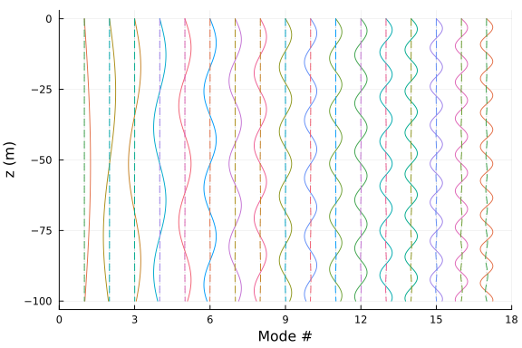

```julia
# plot the modes
plot(modes)
```

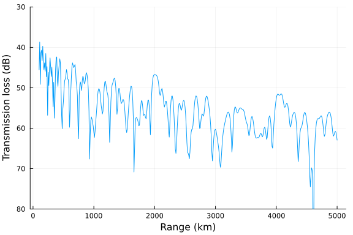

```julia
rxs = AcousticReceiverGrid2D(100:10:5000, -50)
x = transmission_loss(pm, tx, rxs)

plot(100:10:5000, x; ylims=(30,80), yflip=true, legend=false,
  xlabel="Range (km)", ylabel="Transmission loss (dB)")
```

### Range-dependent scenario with multilayered seabed

While the Orca model is range-independent by itself, it can be made range-dependent by using `AdiabaticExt` as shown below:

```julia
using UnderwaterAcoustics
using Plots

env = UnderwaterEnvironment(
  bathymetry = SampledField([200, 150, 200]; x=[0, 2000, 5000]),
  soundspeed = 1500,
  density = 1000,
  seabed = MultilayerElasticBoundary([
    (40, 1374, 1520, 0, dBperλ(0.1124), 0),           # 40m thick fluid sediment
    (Inf, 2200, 1730, 800, dBperλ(0.5), dBperλ(0.5))  # hard half-space substrate
  ])
)

# use an adiabatic extension to the Orca for range-dependence
pm = AdiabaticExt(Orca, env)

tx = AcousticSource(0, -50, 250)
rx = AcousticReceiver(7000, -25)
modes = arrivals(pm, tx, rx)[1:7]      # first 7 modes
```

```
7 element Vector{ModeArrival}:
  mode 1: kᵣ = 1.047089 - 1.0e-6im rad/m, v = 1499.83 m/s, vₚ = 1500.16 m/s
  mode 2: kᵣ = 1.046762 - 3.0e-6im rad/m, v = 1499.30 m/s, vₚ = 1500.62 m/s
  mode 3: kᵣ = 1.046217 - 6.0e-6im rad/m, v = 1498.42 m/s, vₚ = 1501.41 m/s
  mode 4: kᵣ = 1.045452 - 1.0e-5im rad/m, v = 1497.19 m/s, vₚ = 1502.50 m/s
  mode 5: kᵣ = 1.044468 - 1.6e-5im rad/m, v = 1495.59 m/s, vₚ = 1503.92 m/s
  mode 6: kᵣ = 1.043263 - 2.2e-5im rad/m, v = 1493.65 m/s, vₚ = 1505.66 m/s
  mode 7: kᵣ = 1.041837 - 3.1e-5im rad/m, v = 1491.37 m/s, vₚ = 1507.72 m/s
```

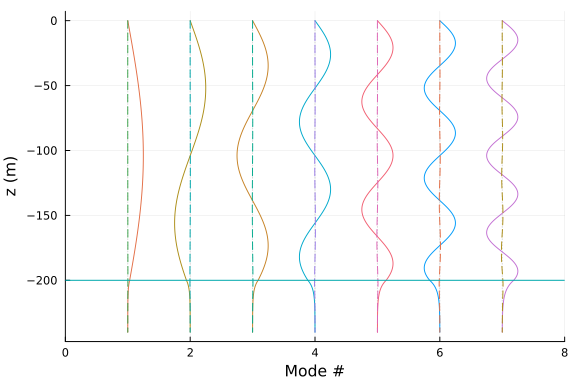

```julia
# plot the modes at 7 km range
plot(modes)
hline!([-200])    # seabed location
```

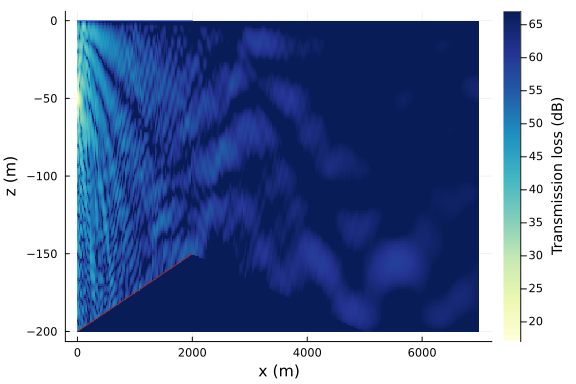

```julia
rxs = AcousticReceiverGrid2D(10:10:7000, -200:-1)
x = transmission_loss(pm, tx, rxs)

plot(rxs, x; crange=50)
plot!(env)
```

## Notes

The Fortran Orca propagation model requires that the transmitter is located at $(x=0, y=0)$ and all receivers are located in the right half-plane (i.e., $x>0$ and $y=0$). This limitation can be worked around by wrapping the model with `Reframe2D`, which automatically transforms 2D scenarios specified in world coordinates into the coordinate system required by the model (see the quickstart guide for an example).